# Military spending of NATO, Ukraine, and Russia since 1990 compared

An exploratorive data analysis

Thomas McKinney

June 10th 2023

# 1 tl;dr

- Countries seem to be more willing to invest a significant amout of their Government spending/GDP on military matters, if they are involved in (civil-)wars.
- No NATO member -not even the USA- or Russia was among the top 10 of the big spenders since 1990 in terms of % of government spending or % of GDP. Ukraine was.

# 2 Version:

Last change: June 16th 2023

# 3 Introduction

I have recently started, to learn R. This is very much a first attempt at a R Notebook, and work in progress. I’m happy for any tips or criticism. :-)

In this notebook, I’m looking at the defense spending of countries that are more or less involved in the ongoing Russian war of aggression against the Ukraine. Meaning that I will look at belligerent nations, as well as the NATO countries which support Ukraine with arms, money, and goods.

The start point of my analysis will be 1990, i.e. the end of the Cold War. I will look at the most up to date Data available at SIPRI and the World Bank. For most countries this is 2021.

Instead of looking at the numbers in cash, I will use two relative indicators:

* How much of their annual budget did the Nations spend on their military? (Budget)

* How much of their annual GDP did the Nations spend on their military? (GDP)

I am assuming, that both values allow me to answer the question: how willing a country was to fund its military. Most governments set their budgets in advance by taking predicted financial forecasts in account. Depending on the actual financial development of a country, one monetary unit will pay for X military spending. So the *actual* spending per year is dependent on the value of the nations currency. Other factors (prices of raw materials, problems in the defense eco system) also contribute to the actual exchange of money for military might per year. Therefor I have chosen the above mentioned indicators. My theory being, that both indicators will provide me with an idea of how much the governments in question were willing to spend on the military. Meaning, I am not simply trying to look at economic figures, but the political will of the respective governments.

I am very much aware, that neither budget nor GDP give the full picture. This would require further qualitative analysis of government documents, experts opinions, NATO summits, etc. I am hoping though, that the numbers will show some trends, and provide some insights that warrant further investigation.

# 4 Loading and arranging the Data

## 4.1 Data Worldwide

### 4.1.1 Government spending

#### 4.1.1.1 Finding Min, Max, Mean of % of Government spending by all countries world wide

```r
dft_sum_government_spending_ww <- dft_government_spending_ww %>%
  select(!c(region, subregion)) %>%
  pivot_longer(!country, names_to = "year", values_to = "spending", values_drop_na = TRUE) %>%
  summarise(
    mean = mean(spending),
    min = min(spending),
    max = max(spending)
  ) %>%
  arrange(desc(mean)) %>%
  as_tibble()
```

### 4.1.2 % of GDP

#### 4.1.2.1 Finding Min, Max, Mean of % of GDP spending by all countries world wide

```r
dft_sum_GDP_ww <- dft_GDP_ww %>%
  select(!c(region, subregion)) %>%
  pivot_longer(!country, names_to = "year", values_to = "spending", values_drop_na = TRUE) %>%
  summarise(
    mean = mean(spending),
    min = min(spending),
    max = max(spending)
  ) %>%
  arrange(desc(mean)) %>%
  as_tibble()
```

Ok, so it seems, that on overage Governments allocated 7.65% of their annual budget to the military. With the minimum being 0.07% and the maximum being 57.5%. In the same time period countries spent an average of 2.25% of their GDP on the military. With the minimum being 0% and the maximum being 117%.

Let’s take a look at who the big spender/s was/were.

```r
dft_government_spending_ww_BigSpender <- dft_government_spending_ww %>%
  select(!c(region, subregion)) %>%
  pivot_longer(!country, names_to = "year", values_to = "spending", values_drop_na = TRUE) %>%
  arrange(desc(spending)) %>%
  slice_head(n=10)

dft_sum_GDP_ww_BigSpender <- dft_GDP_ww %>% select(!c(region, subregion)) %>%
  pivot_longer(!country, names_to = "year", values_to = "spending", values_drop_na = TRUE) %>%
  arrange(desc(spending)) %>%
  slice_head(n=10)
```

```r
dft_government_spending_ww_BigSpender
```

| country | year | spending |
| --- | --- | --- |
| Kuwait | x1991 | 57.48 |
| Kuwait | x1990 | 52.56 |
| Sudan | x1999 | 47.76 |
| Eritrea | x1998 | 47.72 |
| Eritrea | x2000 | 44.03 |
| Sudan | x2000 | 43.16 |
| Eritrea | x1999 | 41.88 |
| Saudi Arabia | x1998 | 41.16 |
| Eritrea | x1993 | 41.00 |
| Somalia | x2014 | 40.44 |

```r
dft_sum_GDP_ww_BigSpender
```

| country | year | spending |
| --- | --- | --- |
| Kuwait | x1991 | 117.35 |
| Kuwait | x1990 | 48.52 |
| Eritrea | x1999 | 34.38 |
| Ukraine | x2022 | 33.55 |
| Eritrea | x2000 | 32.66 |
| Eritrea | x1998 | 32.50 |
| Kuwait | x1992 | 31.79 |
| Liberia | x1994 | 29.73 |
| Eritrea | x2001 | 22.14 |
| Eritrea | x1993 | 21.33 |

So, we do not have a lot surprises here. The big spenders were involved in shooting (civil-)wars. Out of the countries that are the focus of this notebook, only the Ukraine makes the top 10, by allocating 33.55% of it’s GDP to the military in 2022; ie the year it was [attacked by Russia](https://www.eeas.europa.eu/eeas/un-general-assembly-demands-russian-federation-withdraw-all-military-forces-territory-ukraine_en).

*First (underwhelming) thesis:* Countries seem to be more willing to invest a significant amout of their Government spending/GDP on military matters, if they are involved in (civil-)wars.

*Second thesis:* No NATO member -not even the USA- or Russia was among the top 10 of the big spenders since 1990.This is obviously only true as fars as relative values are concerned. In USD we find plenty of the before mentioned nations among military spenders. [With the US obviously in first place, and Russia in third](https://www.statista.com/statistics/262742/countries-with-the-highest-military-spending/). In my opinion (with exception of Saudi Arabia) countries like Eritrea and Sudan do not rank among the big spenders in hard currency, because of their way weaker economic power. Large %’s of “small” GDPs are still small in USD. (insert shrug emoji here)

## 4.2 % of Government spending

## 4.3 Min, Max, Mean of % of Government spending by Country

```r
dft_sum_government_spending <- dft_government_spending %>%
  select(!c(series_code, country_name, natojoin, nato2024)) %>%
  pivot_longer(!country_code, names_to = "year", values_to = "spending", values_drop_na = TRUE) %>%
  group_by(country_code) %>%
  summarise(
    mean = mean(spending),
    min = min(spending),
    max = max(spending)
  ) %>%
  arrange(desc(mean)) %>%
  as_tibble()
dft_sum_government_spending
```

| country_code | mean | min | max |
| --- | --- | --- | --- |
| RUS | 10.966821 | 6.9055170 | 14.828395 |
| USA | 10.737243 | 8.1976241 | 12.444213 |
| HRV | 7.894583 | 3.2530904 | 28.957641 |
| TUR | 6.908679 | 5.4610758 | 9.229623 |
| GBR | 6.609278 | 4.5629171 | 10.556770 |
| ROU | 6.382034 | 3.2779250 | 12.376471 |
| GRC | 6.283711 | 4.5507656 | 8.623751 |
| UKR | 5.812244 | 3.2826997 | 8.513455 |
| BGR | 5.632556 | 3.3376200 | 8.736245 |
| MKD | 5.264902 | 2.8178433 | 16.327851 |

[output cut: 21 more lines]

## 4.4 Min, Max, Mean of % of Government spending by Year

```r
dft_sum_government_spending_PA <- dft_government_spending %>%
  select(!c(series_code, country_name, country_code, natojoin, nato2024)) %>%
  pivot_longer(
    cols = starts_with("x"),
    names_to = "Year",
    names_prefix = "x",
    values_to = "spending",
    values_drop_na = TRUE
  ) %>%
  mutate(Year = as.integer(Year)) %>%
  arrange(desc(Year)) %>%
  group_by(Year) %>%
  summarise(
    mean = mean(spending),
    min = min(spending),
    max = max(spending)
  ) %>%
  as_tibble()
dft_sum_government_spending_PA
```

| Year | mean | min | max |
| --- | --- | --- | --- |
| 1990 | 6.083149 | 3.2901794 | 11.821212 |
| 1991 | 5.797574 | 3.1793866 | 12.376471 |
| 1992 | 6.377051 | 3.0039526 | 19.893720 |
| 1993 | 6.356382 | 2.1958819 | 28.957641 |
| 1994 | 6.018194 | 1.3548015 | 23.853231 |
| 1995 | 4.760520 | 1.3738280 | 21.144595 |
| 1996 | 4.664187 | 1.4657089 | 18.162259 |
| 1997 | 4.794743 | 1.4898762 | 16.870648 |
| 1998 | 4.530347 | 1.5307053 | 11.413401 |
| 1999 | 4.492351 | 1.4441179 | 8.988604 |

[output cut: 22 more lines]

```r
dft_sum_GDP <- dft_GDP %>%
  select(!c(series_code, country_name, natojoin, nato2024)) %>%
  pivot_longer(!country_code, names_to = "year", values_to = "spending", values_drop_na = TRUE) %>%
  group_by(country_code) %>%
  summarise(
    mean = mean(spending),
    min = min(spending),
    max = max(spending)
  ) %>%
  arrange(desc(mean)) %>%
  as_tibble()
dft_GDP
```

| series_code | country_name | country_code | nato2024 | natojoin | x1990 | x1991 | x1992 | x1993 | x1994 | x1995 | x1996 | x1997 | x1998 | x1999 | x2000 | x2001 | x2002 | x2003 | x2004 | x2005 | x2006 | x2007 | x2008 | x2009 | x2010 | x2011 | x2012 | x2013 | x2014 | … |
| --- | --- | --- | --- | --- | --- | --- | --- | --- | --- | --- | --- | --- | --- | --- | --- | --- | --- | --- | --- | --- | --- | --- | --- | --- | --- | --- | --- | --- | --- | --- |
| MS.MIL.XPND.GD.ZS | Albania | ALB | 1 | 2009 | 5.8883007 | 5.7912704 | 4.6708878 | 3.1994511 | 2.5478191 | 2.0535874 | 1.3790296 | 1.2830808 | 1.2382426 | 1.2492101 | 1.2463602 | 1.3092914 | 1.3200345 | 1.3368429 | 1.3811579 | 1.3500050 | 1.5677691 | 1.8207653 | 1.9848689 | 1.5172171 | 1.5585919 | 1.5282663 | 1.4870826 | 1.4089821 | 1.3465160 | … |
| MS.MIL.XPND.GD.ZS | Belgium | BEL | 1 | 1949 | 2.3554405 | 2.2876928 | 1.8323325 | 1.7359659 | 1.6771432 | 1.5657522 | 1.5401027 | 1.4769758 | 1.4639193 | 1.3858356 | 1.3412103 | 1.2765042 | 1.2157122 | 1.2149882 | 1.1492721 | 1.0915601 | 1.0512392 | 1.0945353 | 1.2138983 | 1.1600399 | 1.0846329 | 1.0435068 | 1.0417565 | 1.0089595 | 0.9709598 | … |
| MS.MIL.XPND.GD.ZS | Bulgaria | BGR | 1 | 2004 | 3.8334435 | 3.0432316 | 2.9726338 | 2.6092716 | 2.4926173 | 2.3741313 | 2.4029341 | 2.4307014 | 2.4530591 | 2.6451720 | 2.6711705 | 2.8844614 | 2.8012596 | 2.7120207 | 2.3919935 | 2.2528982 | 2.0969913 | 2.2296113 | 2.1335248 | 1.7395115 | 1.6524682 | 1.3207173 | 1.3363553 | 1.4593401 | 1.3137045 | … |
| MS.MIL.XPND.GD.ZS | Canada | CAN | 1 | 1949 | 1.9587937 | 1.8954443 | 1.8616877 | 1.8217535 | 1.6966803 | 1.5540901 | 1.4037526 | 1.2462432 | 1.2562939 | 1.2417031 | 1.1180809 | 1.1373690 | 1.1208523 | 1.1158788 | 1.1079660 | 1.1106697 | 1.1258324 | 1.1889018 | 1.2486214 | 1.3775556 | 1.1943383 | 1.1932919 | 1.1184046 | 1.0023672 | 0.9899253 | … |
| MS.MIL.XPND.GD.ZS | Croatia | HRV | 1 | 2009 | NA | NA | 7.6073864 | 10.7267571 | 11.1481773 | 9.3150104 | 8.2920111 | 8.9424925 | 6.6002195 | 4.4296297 | 3.0300558 | 2.7027738 | 2.7306333 | 2.0462989 | 1.7601437 | 1.7623284 | 1.6858051 | 1.6284306 | 1.8451879 | 1.7898345 | 1.6811906 | 1.7515682 | 1.6703631 | 1.6250085 | 1.8231861 | … |
| MS.MIL.XPND.GD.ZS | Czechia | CZE | 1 | 1999 | NA | NA | NA | 2.3304041 | 2.2834009 | 1.8436228 | 1.7319047 | 1.6620458 | 1.8259318 | 1.8590699 | 1.8773570 | 1.7512496 | 1.8244070 | 1.8927640 | 1.7137032 | 1.7900838 | 1.5759062 | 1.4309147 | 1.2324716 | 1.3105641 | 1.1947722 | 1.0778365 | 1.0632168 | 1.0150837 | 0.9662278 | … |
| MS.MIL.XPND.GD.ZS | Denmark | DNK | 1 | 1949 | 1.9507570 | 1.9546801 | 1.8893773 | 1.9071977 | 1.7701099 | 1.6853147 | 1.6448167 | 1.6159612 | 1.6080264 | 1.5648547 | 1.4574441 | 1.5323807 | 1.5081499 | 1.4668512 | 1.4237042 | 1.3114886 | 1.3774922 | 1.3072471 | 1.3550045 | 1.3501786 | 1.3986218 | 1.3135313 | 1.3518190 | 1.2272520 | 1.1492733 | … |
| MS.MIL.XPND.GD.ZS | Estonia | EST | 1 | 2004 | NA | NA | NA | 0.7617520 | 1.0416303 | 0.9580983 | 0.8735961 | 1.0467725 | 1.0674917 | 1.2871134 | 1.3763271 | 1.5022145 | 1.6671295 | 1.7430493 | 1.6996892 | 1.4509199 | 1.3884224 | 1.6575821 | 1.7650497 | 1.7889384 | 1.6864701 | 1.6640102 | 1.8835796 | 1.8966666 | 1.9127859 | … |
| MS.MIL.XPND.GD.ZS | France | FRA | 1 | 1949 | 2.8052676 | 2.8121364 | 2.6906607 | 2.6895348 | 2.6603750 | 2.4924962 | 2.4144740 | 2.3754097 | 2.2262083 | 2.1778430 | 2.0850182 | 2.0306953 | 2.0462580 | 2.0956804 | 2.1043508 | 2.0237069 | 1.9750983 | 1.9075286 | 1.8970759 | 2.0981473 | 1.9694194 | 1.8914062 | 1.8710806 | 1.8498759 | 1.8629614 | … |
| MS.MIL.XPND.GD.ZS | Germany | DEU | 1 | 1955 | 2.5184327 | 1.9978350 | 1.8604799 | 1.6935383 | 1.5502764 | 1.4950220 | 1.4658585 | 1.4093017 | 1.3908948 | 1.3950744 | 1.3588830 | 1.3234383 | 1.3279581 | 1.3169249 | 1.2689574 | 1.0656297 | 1.1993030 | 1.1724718 | 1.2090340 | 1.3106041 | 1.2668266 | 1.2061503 | 1.2416775 | 1.1852579 | 1.1499420 | … |

[output cut: 22 more lines]

# 5 Analysis

## 5.1 % of Government spending

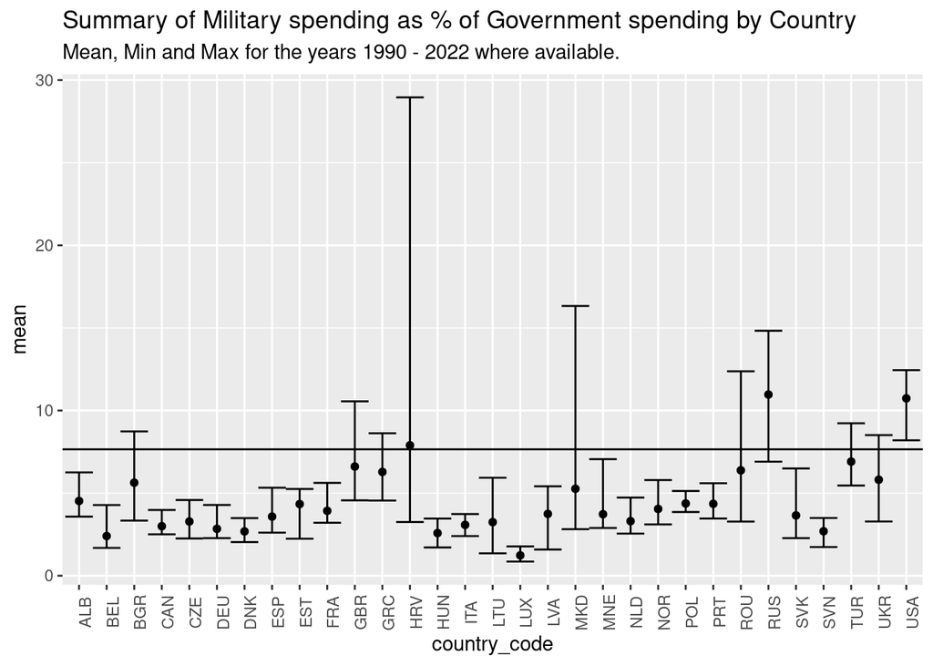

```r
intercept <- dft_sum_government_spending_ww$mean

ggplot(dft_sum_government_spending)+
  geom_errorbar(
    mapping = aes(
      x=country_code, ymin=min, ymax=max
      ),
    width = 1
    )+
  geom_point(
    mapping = aes(
      x = country_code,
      y = mean,
    )
  )+
  scale_x_discrete(
    labels=abbreviate
  )+
  geom_hline(
    yintercept= intercept
  )+
  labs(
    title="Summary of Military spending as % of Government spending by Country",
    subtitle = "Mean, Min and Max for the years 1990 - 2022 where available."
  )+
  theme(
    axis.text.x = element_text(angle = 90)
  )
```

```r
dft_sum_government_spending
```

| country_code | mean | min | max |
| --- | --- | --- | --- |
| RUS | 10.966821 | 6.9055170 | 14.828395 |
| USA | 10.737243 | 8.1976241 | 12.444213 |
| HRV | 7.894583 | 3.2530904 | 28.957641 |
| TUR | 6.908679 | 5.4610758 | 9.229623 |
| GBR | 6.609278 | 4.5629171 | 10.556770 |
| ROU | 6.382034 | 3.2779250 | 12.376471 |
| GRC | 6.283711 | 4.5507656 | 8.623751 |
| UKR | 5.812244 | 3.2826997 | 8.513455 |
| BGR | 5.632556 | 3.3376200 | 8.736245 |
| MKD | 5.264902 | 2.8178433 | 16.327851 |

[output cut: 21 more lines]

### 5.1.1 Summary by year

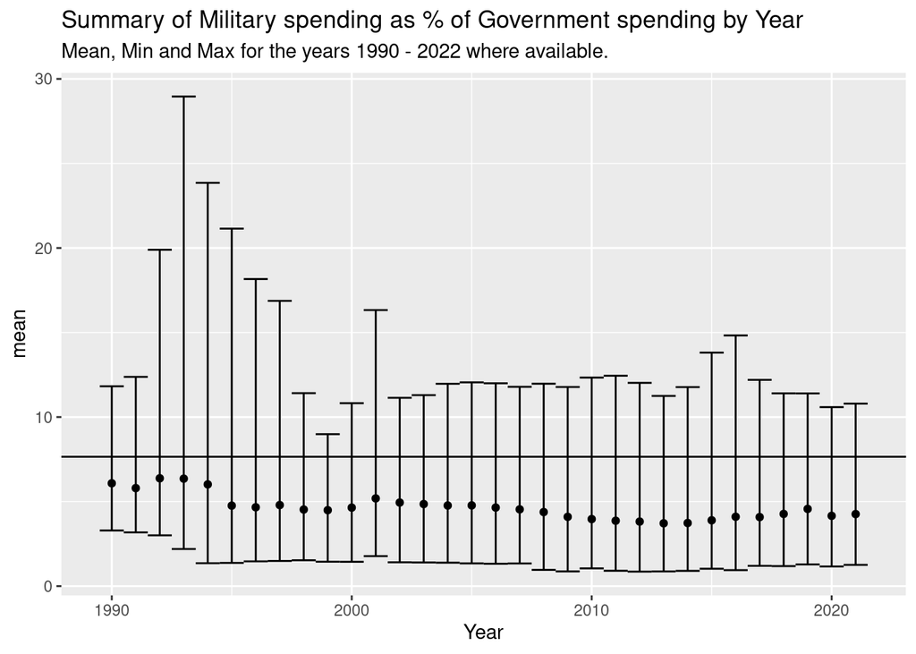

```r
ggplot(dft_sum_government_spending_PA)+
  geom_errorbar(
    mapping = aes(
      x=Year, ymin=min, ymax=max
      ),
    width = 1
    )+
  geom_point(
    mapping = aes(
      x = Year,
      y = mean,
    )
  )+
  geom_hline(
    yintercept= intercept
  )+
  labs(
    title="Summary of Military spending as % of Government spending by Year",
    subtitle = "Mean, Min and Max for the years 1990 - 2022 where available."
  )
```

```r
dft_sum_government_spending_PA
```

| Year | mean | min | max |
| --- | --- | --- | --- |
| 1990 | 6.083149 | 3.2901794 | 11.821212 |
| 1991 | 5.797574 | 3.1793866 | 12.376471 |
| 1992 | 6.377051 | 3.0039526 | 19.893720 |
| 1993 | 6.356382 | 2.1958819 | 28.957641 |
| 1994 | 6.018194 | 1.3548015 | 23.853231 |
| 1995 | 4.760520 | 1.3738280 | 21.144595 |
| 1996 | 4.664187 | 1.4657089 | 18.162259 |
| 1997 | 4.794743 | 1.4898762 | 16.870648 |
| 1998 | 4.530347 | 1.5307053 | 11.413401 |
| 1999 | 4.492351 | 1.4441179 | 8.988604 |

[output cut: 22 more lines]

## 5.2 % of GDP

[figure not shown]

```r
ggplot(dft_sum_GDP)+
  geom_errorbar(
    mapping = aes(
      x=country_code, ymin=min, ymax=max
      ),
    width = 1
    )+
  geom_point(
    mapping = aes(
      x = country_code,
      y = mean,
    )
  )+
  scale_x_discrete(
    labels=abbreviate
  )+
  labs(
    title="Summary of Military spending as % of Government spending by Country",
    subtitle = "Mean, Min and Max for the years 1990 - 2022 where available."
  )
```

```r
dft_sum_GDP
```

| country_code | mean | min | max |
| --- | --- | --- | --- |
| USA | 3.9561419 | 3.0856768 | 5.6051753 |
| RUS | 3.7985092 | 2.7326491 | 5.4251477 |
| HRV | 3.6422412 | 1.5524900 | 11.1481773 |
| GRC | 3.0109306 | 2.3507829 | 3.8673696 |
| TUR | 2.9000431 | 1.8128483 | 4.1396969 |
| GBR | 2.5867276 | 1.9195492 | 4.1168024 |
| UKR | 2.2995678 | 0.3523529 | 3.8118495 |
| ROU | 2.2180370 | 1.2323827 | 4.7733347 |
| BGR | 2.1785752 | 1.2262437 | 3.8334435 |
| FRA | 2.1370376 | 1.8364615 | 2.8121364 |

[output cut: 21 more lines]

## 5.3 Summary by year

```r
summary(dft_GDP)
```

```
##  series_code        country_name       country_code          nato2024
##  Length:32          Length:32          Length:32          Min.   :1
##  Class :character   Class :character   Class :character   1st Qu.:1
##  Mode  :character   Mode  :character   Mode  :character   Median :1
##                                                           Mean   :1
##                                                           3rd Qu.:1
##                                                           Max.   :1
##                                                           NA's   :2
##     natojoin        x1990            x1991            x1992
##  Min.   :1949   Min.   :0.7883   Min.   :0.8114   Min.   :0.8272
##  1st Qu.:1949   1st Qu.:2.3399   1st Qu.:2.0964   1st Qu.:1.9661
##  Median :1968   Median :2.5880   Median :2.3554   Median :2.3904
##  Mean   :1977   Mean   :3.0302   Mean   :2.8713   Mean   :3.0106
##  3rd Qu.:2004   3rd Qu.:3.8071   3rd Qu.:3.5522   3rd Qu.:3.8676
##  Max.   :2017   Max.   :5.8883   Max.   :5.7913   Max.   :7.6074
##  NA's   :2      NA's   :12       NA's   :12       NA's   :9
##      x1993             x1994             x1995            x1996
##  Min.   : 0.3524   Min.   : 0.4934   Min.   :0.4544   Min.   :0.504
##  1st Qu.: 1.7868   1st Qu.: 1.6967   1st Qu.:1.5541   1st Qu.:1.483
##  Median : 2.0278   Median : 2.0013   Median :1.9555   Median :1.891
##  Mean   : 2.5445   Mean   : 2.5478   Mean   :2.3162   Mean   :2.231
##  3rd Qu.: 2.7406   3rd Qu.: 2.7331   3rd Qu.:2.6134   3rd Qu.:2.647
##  Max.   :10.7268   Max.   :11.1482   Max.   :9.3150   Max.   :8.292
##  NA's   :3         NA's   :3         NA's   :3        NA's   :2
##      x1997            x1998            x1999            x2000
##  Min.   :0.5821   Min.   :0.5878   Min.   :0.5714   Min.   :0.5441
##  1st Qu.:1.4261   1st Qu.:1.3686   1st Qu.:1.3881   1st Qu.:1.3632
##  Median :1.8694   Median :1.7916   Median :1.7345   Median :1.7333
##  Mean   :2.2369   Mean   :2.0455   Mean   :1.9563   Mean   :1.9061
##  3rd Qu.:2.5278   3rd Qu.:2.3963   3rd Qu.:2.3616   3rd Qu.:2.3174
##  Max.   :8.9425   Max.   :6.6002   Max.   :4.4296   Max.   :3.6611
##  NA's   :2        NA's   :2        NA's   :2        NA's   :2
##      x2001            x2002            x2003            x2004
##  Min.   :0.6803   Min.   :0.5868   Min.   :0.6072   Min.   :0.6112
##  1st Qu.:1.3809   1st Qu.:1.4339   1st Qu.:1.4279   1st Qu.:1.4277
##  Median :1.7279   Median :1.8002   Median :1.8632   Median :1.7067
##  Mean   :2.0621   Mean   :1.9903   Mean   :1.9302   Mean   :1.8553
##  3rd Qu.:2.4183   3rd Qu.:2.4361   3rd Qu.:2.1171   3rd Qu.:2.0802
##  Max.   :6.1004   Max.   :3.7959   Max.   :3.8272   Max.   :4.0163
##  NA's   :2        NA's   :2        NA's   :2        NA's   :2
```

[output cut: 25 more lines]

```
##  Min.   :0.5249   Min.   :0.5298   Min.   :0.5745   Min.   :0.6273
##  1st Qu.:1.1235   1st Qu.:1.1923   1st Qu.:1.2732   1st Qu.:1.3922
##  Median :1.3628   Median :1.4516   Median :1.7119   Median :1.8566
##  Mean   :1.6230   Mean   :1.6933   Mean   :1.8189   Mean   :1.9417
##  3rd Qu.:1.9018   3rd Qu.:1.9880   3rd Qu.:2.0156   3rd Qu.:2.2479
##  Max.   :4.2490   Max.   :3.6925   Max.   :3.8321   Max.   :4.2634
##  NA's   :1        NA's   :1        NA's   :1        NA's   :1
##      x2021         x2022
##  Min.   :0.6269   Mode:logical
##  1st Qu.:1.4190   NA's:32
##  Median :1.7429
##  Mean   :1.9487
##  3rd Qu.:2.1380
##  Max.   :4.0801
##  NA's   :1
```